# Considering the effect of Bait vs. Lure on Wolverine Occupancy and Detection

Brian D. Gerber and Jacob S. Ivan

2025-07-22

# **Context**

In the 2017 and 2022 WAFWA wolverine surveys, camera sites included either bait and lure (labeled as bait below) or only a scent lure (labeled as lure below).

We are interested in understanding the effects of bait and lure in detecting wolverine at a site.

This includes:

- how detection probability could be different at occupied sites when using bait vs lure and
- whether there is an effect of detecting wolverine at all at a site using lure; i.e., a wolverine is present but may go undetected using lure but will be detected using bait.

The first part can be addressed pretty easily as we can estimate different detection probabilities for a site labeled as bait vs lure.

The second part is more challenging. This is a more insidious problem. We can investigate this by conditioning on sites what were occupied in 2017 and asking if the change in occupancy (colonization/extirpation) is different based on whether a site was baited both years or used lure both years or changed from bait to lure. Unfortunately, no sites that used lure in 2017 were then baited in 2022. There should not be a difference in colonization or extirpation by this change.

There are a lot of data summary tables below that could be skipped. The main investigation is presented in the section: `Dynamic Occupancy Model`.

# **Spatial Distribution**

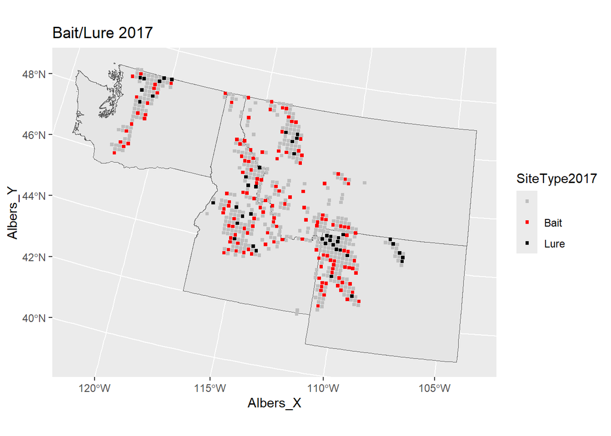

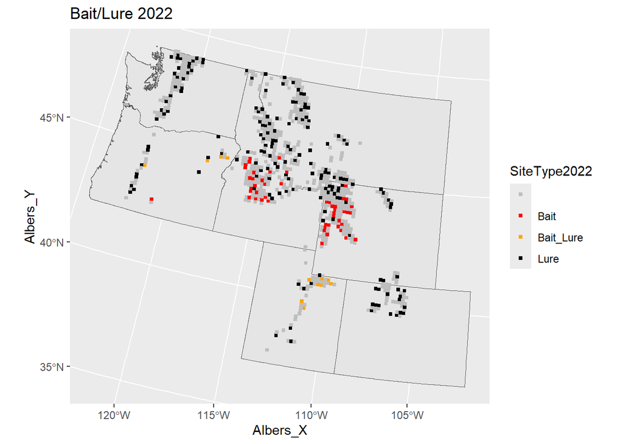

**Summary:** Sites that got bait or lure were not randomly assigned. There could be some correlating factor of site differences that is not really due to detection method. For example, sites with difficulty accessibility in 2017 often used lure. Also, in 2022 the sites with wolverines present and had plenty of baited sites were only Idaho and Wyoming. Need to think about both concerns when evaluating the effect of detection method.

# **Covariate Comparison**

Comparisons of the available spatial covariates by year between sites with bait or lure.

### *2017:*

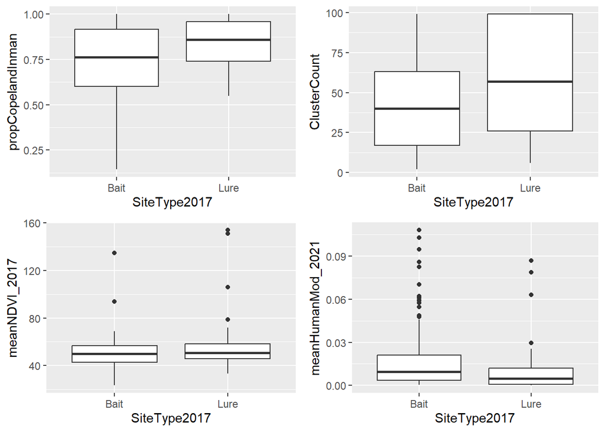

### *2022:*

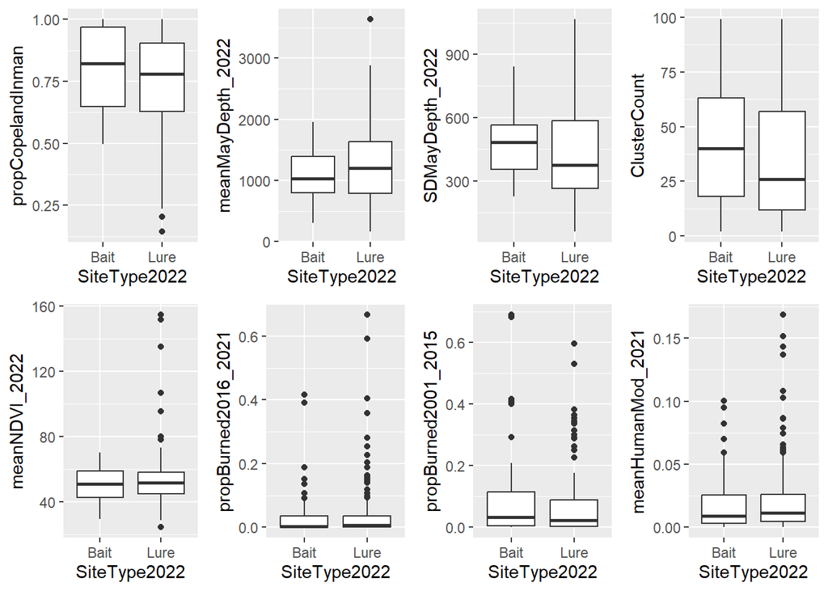

**Summary:*** The differences b/w lure and bait sites are not overwhelming in any of these covariates. In 2017, sites with lure had a higher range and upper 75% quantile in `ClusterCount`, meaning the sites were more connected than bait sites. This might be related to these sites being more inaccessible.

# **Data Summary**

### Number of sampled sites

*2017:*

| Site.Type | 2017.Count | 2022.Count |
| --- | --- | --- |
| Bait | 141 | 62 |
| Lure | 43 | 167 |

**Summary:** 2017 was mostly baited sites and 2022 was mostly lure sites.

### Number of sampled sites by state

*2017:*

|  | Idaho | Montana | Washington | Wyoming |
| --- | --- | --- | --- | --- |
| Bait | 48 | 43 | 18 | 32 |
| Lure | 11 | 5 | 8 | 19 |

*2022:*

|  | Colorado | Idaho | Montana | Oregon | Utah | Washington | Wyoming |
| --- | --- | --- | --- | --- | --- | --- | --- |
| Bait | 0 | 22 | 0 | 5 | 9 | 0 | 26 |
| Lure | 16 | 37 | 46 | 11 | 6 | 26 | 25 |

**Summary**: MT and WA (which have wolverines) have no baited sites; ID and WY have a good number of baited sites in both years and have wolverines.

### Count of all detections/non-detections

These are counts summarizing for all sampling occasions.

*2017:*

|  | 0 | 1 |
| --- | --- | --- |
| Bait | 465 | 99 |
| Lure | 159 | 13 |

*2022:*

|  | 0 | 1 |
| --- | --- | --- |
| Bait | 173 | 75 |
| Lure | 638 | 30 |

**Summary**: 2017 detections mostly occured at baited sites (99 vs 13), but also there were more of these type sites. 2022 detections were more often at baited sites (75 vs 30), when there were less baited sites.

### Trap success

Count of detections/count of sampling occasions

*2017:*

| Site.Type | Count.Detections | Trap Success |
| --- | --- | --- |
| Bait | 99 | 0.176 |
| Lure | 13 | 0.076 |

*2022:*

| Site.Type | Count.Detections | Trap Success |
| --- | --- | --- |
| Bait | 75 | 0.302 |
| Lure | 30 | 0.045 |

**Summary**: After correcting the count of detections by the number of sampling occassions (per bait/lure) we see that we get a higher trap success at bait sites compared to lure sites in both years.

### Count of detections by State

*2017:*

|  | Idaho | Montana | Washington | Wyoming |
| --- | --- | --- | --- | --- |
| Bait | 37 | 44 | 9 | 9 |
| Lure | 4 | 6 | 3 | 0 |

*2022:*

|  | Idaho | Montana | Washington | Wyoming |
| --- | --- | --- | --- | --- |
| Bait | 51 | 0 | 0 | 24 |
| Lure | 8 | 13 | 6 | 3 |

### Count of sites with detections

Sum of sites with at least one detection by Bait/Lure.

*2017:*

|  | Idaho | Montana | Washington | Wyoming |
| --- | --- | --- | --- | --- |
| Bait | 17 | 19 | 7 | 6 |
| Lure | 2 | 2 | 2 | 0 |

*2022:*

|  | Idaho | Montana | Washington | Wyoming |
| --- | --- | --- | --- | --- |
| Bait | 17 | 0 | 0 | 11 |
| Lure | 3 | 8 | 3 | 2 |

### Naive Site Occupancy

*2017:*

| Detection | Site.Type | Count.Occupied | Total | Prop.Occupied.Naive |
| --- | --- | --- | --- | --- |
| 0 | Bait | 92 | 141 | 0.6524823 |
| 1 | Bait | 49 | 141 | 0.3475177 |
| 0 | Lure | 37 | 43 | 0.8604651 |
| 1 | Lure | 6 | 43 | 0.1395349 |

*2022:*

| Detection | Site.Type | Count.Occupied | Total | Prop.Occupied.Naive |
| --- | --- | --- | --- | --- |
| 0 | Bait | 34 | 63 | 0.5396825 |
| 1 | Bait | 28 | 63 | 0.4444444 |
| 0 | Lure | 151 | 167 | 0.9041916 |
| 1 | Lure | 16 | 167 | 0.0958084 |

**Summary**: Naive occupancy of baited sites in 2017 is higher (0.34) than lure sites in (0.14). Naive occupancy of baited sites in 2022 is higher (0.44) than lure sited in (0.10).

### Naive Site Occupancy for WY and ID

WY and ID are the only states with a good number of baited sites in both years.

*2017:*

|  | Site.Type | State | Count.Occ.Sites | Naive.Occ |
| --- | --- | --- | --- | --- |
| 5 | Bait | Idaho | 17 | 0.3541667 |
| 6 | Lure | Idaho | 2 | 0.1818182 |
| 7 | Bait | Wyoming | 6 | 0.1875000 |
| 8 | Lure | Wyoming | 0 | 0.0000000 |

*2022*

|  | Site.Type | State | Count.Occ.Sites | Naive.Occ |
| --- | --- | --- | --- | --- |
| 5 | Bait | Idaho | 17 | 0.7727273 |
| 6 | Lure | Idaho | 3 | 0.0789474 |
| 7 | Bait | Wyoming | 11 | 0.4230769 |
| 8 | Lure | Wyoming | 2 | 0.0800000 |

**Summary**: In both states and in both years, naive occupancy is higher at baited sites than lure sites. Notice especially that naive occupancy at baited sites increase from 2017 to 2022. This will pertain to understanding one of the results in the dynamic occupancy model below.

### Number of sampled sites by detection method

Summary of the shared sites in both surveys (2017, 2022) and how the detection method (Bait, Lure) changed. BaitBait indicates bait at a sites was in 2017 and 2022, while BaitLure indicates bait was used in 2017 and then changed to lure in 2022.

|  | BaitBait | BaitLure | LureLure |
| --- | --- | --- | --- |
| Idaho | 22 | 25 | 11 |
| Montana | 0 | 41 | 5 |
| Washington | 0 | 18 | 8 |
| Wyoming | 26 | 2 | 19 |

### Change in site detection (2022-2017) for MT and WA

Idaho, Montana, and Washington had a lot of bait sites in 2017 that then used lure in 2022 (25, 41 and 18, respectively). If lure decreases the chance of a site getting a wolverine detection in an “assumed occupied site”, these are the two states that would see the biggest change.

We will summarize the number of sites change in naive occupancy status by whether they were baited in 2017 and then used lure (BaitLure) or used lure in both years (LureLure).

|  | BaitBait | BaitLure | LureLure |
| --- | --- | --- | --- |
| -1 | 4 | 20 | 4 |
| 0 | 12 | 60 | 18 |
| 1 | 6 | 4 | 2 |

A `-1` indicates a site that had no detection in 2022 and a detection in 2017

A `0` indicates a site did not change detection status b/w years; either detections in both years or no detections in both years

A `1` indicates a site that had a detection in 2022 and no detection in 2017

**This is for Idaho, Washington and Montana only:**

**Summary:** A disproportionately high number of sites that had a detection in 2017 had no detection in 2022 when the site went from bait to lure; also though, 60 sites went unchanged going from bait to lure. That is good, but includes both sites with no detections as well as sites with detections in both years.

Getting more specific, lets condition on sites with bait in 2017 and a wolverine detection (removes the issue of both sites having no detections, as in the above). This is then those sites in 2022:

|  | 0 | 1 |
| --- | --- | --- |
| Bait | 4 | 11 |
| Lure | 20 | 6 |

### Changes from 2017 to 2022 (all states)

If a site was baited in 2017 and had a detection then this is whether there was a detection (1) or not (0) at bait/lure sites in 2022.

|  | Bait | Lure |
| --- | --- | --- |
| 0 | 6 | 20 |
| 1 | 15 | 6 |

- If detected with bait in 2017: 15/21 (0.71) sites had detections with bait in 2022
- If detected with bait in 2017: 6/26 (0.23) sites had detections with lure in 2022

If a site used lure in 2017 and had a detection then this is whether there was a detection (1) or not (0) at bait/lure sites in 2022.

|  | Lure |
| --- | --- |
| 0 | 4 |
| 1 | 2 |

- If detected with lure in 2017: 2 sites had detections with lure out of 6 (0.333)

### Examine Bait –> Lure Data by State

|  | Idaho | Montana | Washington | Wyoming |
| --- | --- | --- | --- | --- |
| -1 | 2 | 12 | 6 | 0 |
| 0 | 21 | 28 | 11 | 2 |
| 1 | 2 | 1 | 1 | 0 |

A `-1` indicates a site that had no detection in 2022 and a detection in 2017

A `1` indicates a site that had a detection in 2022 and no detection in 2017

This is only for bait (2017) and then lure (2022) cells sites

- lost 2 but gained 2 in ID
- lost 12 and gained 1 in MT
- lost 6 and gained 1 in WA
- lost none and gained none in WY

```
##
##      Idaho Wyoming
##   -1     4       2
##   0     12      17
##   1      6       7
```

- Lost 4 sites in ID and gained 6
- Lots 2 sites in WY and gained 7

### Some Summary Notes

- No sites with Lure in 2017 were then baited in 2022; thus can only asses if baited sites in 2017 that in 2022 had lure and went from detected to not-detected
- If using bait in both year, more likely (two-three times) to get a site detection than if changing to lure in the second year.
- Issue that there is a spatial bias towards certain states with bait/lure.
- Issue that there was no randomization of bait/lure.

# **Dynamic Occupancy Model**

Here, I put the two surveys together for the shared sites only (177 sites). The model allows us to asses if bait/lure sites are different (initial occupancy, detection) and whether changes in occupancy (colonization, extirpation) are different if going from Bait-Bait, Bait-Lure, or Lure-Lure.

## Map of shared sample sites

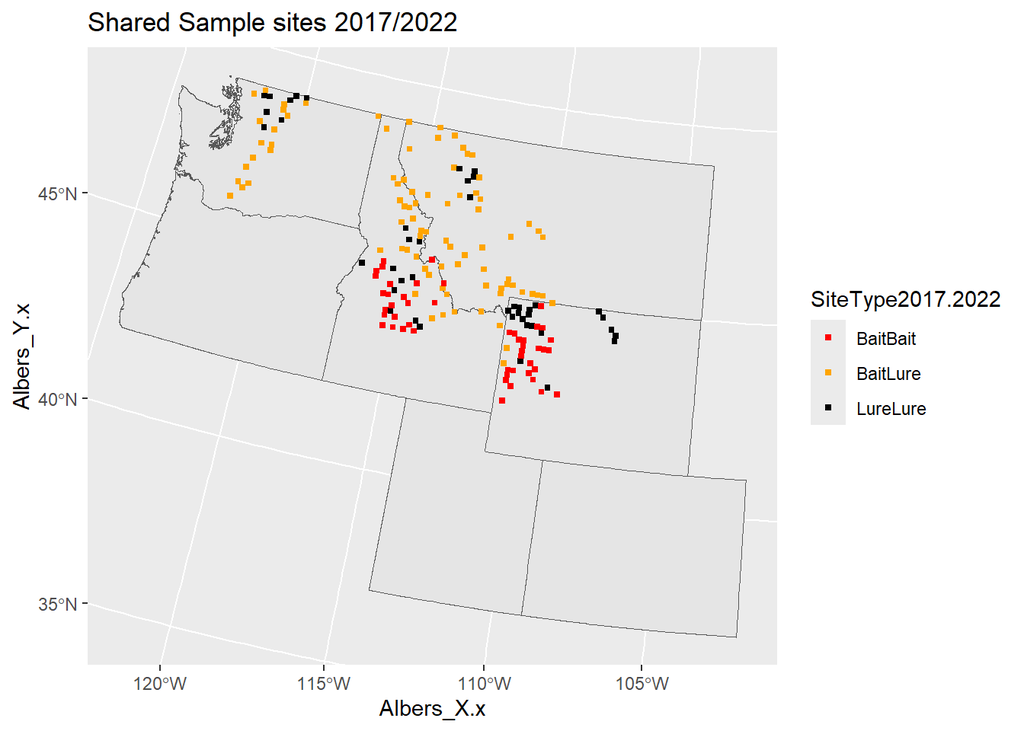

## Model Summary:

```
##
## Call:
## stan_colext(psiformula = ~bait1, gammaformula = ~baitTrans, epsilonformula = ~baitTrans,
##     pformula = ~bait.obs, data = umf, chains = 1)
##
## Occupancy (logit-scale):
##             Estimate    SD   2.5%  97.5% n_eff  Rhat
## (Intercept)   -0.542 0.185 -0.896 -0.196  1366 0.999
## bait1Lure     -1.097 0.486 -2.090 -0.179  1154 1.000
##
## Colonization (logit-scale):
##                   Estimate    SD  2.5%  97.5% n_eff  Rhat
## (Intercept)         -0.244 0.388 -1.02  0.558   740 0.999
## baitTransBaitLure   -2.283 0.657 -3.68 -1.148   825 1.001
## baitTransLureLure   -1.742 0.691 -3.29 -0.505   710 1.002
##
## Extinction (logit-scale):
##                   Estimate    SD   2.5%  97.5% n_eff Rhat
## (Intercept)         -0.785 0.464 -1.800 0.0668   874    1
## baitTransBaitLure    1.701 0.645  0.457 2.9679   938    1
## baitTransLureLure    0.852 1.047 -1.404 2.6639   747    1
##
## Detection (logit-scale):
##              Estimate    SD    2.5%  97.5% n_eff  Rhat
## (Intercept)     0.147 0.127 -0.0998 0.4068  1166 1.000
## bait.obsLure   -0.471 0.290 -1.0613 0.0753  1031 0.999
##
## LOOIC: 905.634
## Runtime: 14.467 sec
```

## Model Probability Predictions

### *Initial Occupancy (2017):*

| Site.Type | Predicted | SD | 2.5% | 97.5% |
| --- | --- | --- | --- | --- |
| Bait | 0.369 | 0.043 | 0.290 | 0.451 |
| Lure | 0.171 | 0.061 | 0.076 | 0.303 |

**Summary:** Occupancy probability in 2017 is lower at sites that used lure. This is after accounting for the lower detection probability due to lure. It is irrelevant that more sites in 2017 used bait as we are scaling by how many there are of each site type (bait or lure).

### Colonization of Site in 2022 that was not Occupied in 2017:

| Site.Type | Predicted | SD | 2.5% | 97.5% |
| --- | --- | --- | --- | --- |
| BaitBait | 0.441 | 0.092 | 0.265 | 0.636 |
| BaitLure | 0.083 | 0.038 | 0.024 | 0.174 |
| LureLure | 0.133 | 0.062 | 0.036 | 0.275 |

**Summary:** I don’t think we can assume there aren’t true changes in occupancy happening, but those changes are exacerbated because of changes in detection method (bait–>lure). Bait–> Bait sites have a high probability of colonization. This change is not due to detection method. However, there is a much lower probability of colonization from a site that changes from bait to lure, indicating an effect of detection method. This colonization is not really different than Lure–>Lure.

Basically, if you use lure at a site that was previously unoccupied, you are not likely to have the site become colonized. This is not true when using bait. Why should a baited site in both years go from unoccupied to occupied? This seems like a real dynamic change. Why is colonization for LureLure, so low? It could be these sites are inherently different than bait sites because they are inaccessible and maybe that means something also a wolverine.

### Extirpation of Site in 2022 that was occupied in 2017

| Site.Type | Predicted | SD | 2.5% | 97.5% |
| --- | --- | --- | --- | --- |
| BaitBait | 0.321 | 0.095 | 0.142 | 0.517 |
| BaitLure | 0.705 | 0.095 | 0.497 | 0.868 |
| LureLure | 0.520 | 0.197 | 0.104 | 0.857 |

**Summary** Again, I don’t think we can assume there aren’t true changes in occupancy happening, but those changes are exacerbated because of changes in detection method (bait–>lure). Bait–>Bait sites have a lower probability of extirpation. But, it’s not zero, so some dynamic changes irrespective of detection method. Bait–>Lure extirpation probability is higher. The difference between the two may be the detection method. There is high uncertainty in extirpation probability for Lure–>Lure, making it hard to interpret.

If you use lure at a site that was previously occupied and used bait previously, you have a high probability of extirpation. This bump in probability beyond Bait–>Bait is likely a detection method.

### Detection Probability of an Occupied Site:

| Site.Type | Predicted | SD | 2.5% | 97.5% |
| --- | --- | --- | --- | --- |
| Bait | 0.536 | 0.031 | 0.475 | 0.600 |
| Lure | 0.421 | 0.062 | 0.295 | 0.539 |

Let’s convert these per occasion probabilities to the probability of detecting a wolverine at least once at an occupied site (p*)….

```
## [1] 0.9538152 0.8874440
```

### Predicted Site Occupancy for 2017 and 2022:

Predict occupancy from the dynamic parameters and compare across the two years how occupancy changes depending on the detection method.

*Occupancy at site with bait both surveys (2017,2022)*

```
## [1] 0.3688416 0.5287772
```

There is an increase in occupancy!

*Occupancy at site with bait (2017) and then lure (2022)*

```
## [1] 0.3688416 0.1610231
```

There is a decrease in occupancy.

*Occupancy at site with lure (2017) and then lure (2022)*

```
## [1] 0.1713117 0.1927063
```

Occupancy is basically the same.

Summary: My major takeaway is that there are dynamics going on at all sites, probably due to wolverines moving around and sampling variation. However, there seems to also be an effect of detection method. Sites with bait in both years have a moderate increase in mean occupancy, while when changing to lure from bait, occupancy decreases. We would expect no change in a site that uses lure in both years and that is exactly what we see.

The fundamental question because bait/lure site designations were not randomized, is what is different between these bait sites and lure sites in 2017? Regardless of those differences though, a baited site that then used lure should not be different than a baited site in both years, unless the detection method is causing a change on detecting wolverines at all at those sites.

When we are examining BaitBait sites, we are only examining sites in Wyoming and Idaho. When we are examining BaitLure sites, we are looking at sites from Idaho, Montana, Washington, and Wyoming. Should we expect different dynamic parameters (by BaitBait, BaitLure) because of the locations of these two samples?